# Study on Android Games

## Introduction

### Where and how the dataset is gathered?

This dataset, *Top Games on Google is through [Kaggle](https://www.kaggle.com/datasets) by searching the keyword* videogames*. Dataset Top Games on Google Play Store was collected by **Dhruvil Dave** through **Google Play Store** directly. He gathered these information by collecting the information shown in the game details page.This dataset was gathered around* Jun 2021*,containing 100 games and 17 game-types categories available in in android Google Play.

### Aggregated Table

The table listed illustrating the 4 numerical variables and their relationship with the game genre.

# Total amount of rating.

| category | Average_total_rating |
| --- | --- |
| GAME ACTION | 4011343.6 |
| GAME CASUAL | 2470866.0 |
| GAME STRATEGY | 1856569.8 |
| GAME ARCADE | 1793779.9 |
| GAME SPORTS | 1353828.8 |
| GAME RACING | 1139026.8 |
| GAME PUZZLE | 946692.9 |
| GAME SIMULATION | 934141.7 |
| GAME ADVENTURE | 893561.7 |
| GAME ROLE PLAYING | 708764.8 |
| GAME BOARD | 445743.1 |
| GAME WORD | 394360.3 |
| GAME CASINO | 361903.1 |
| GAME CARD | 332604.1 |
| GAME TRIVIA | 298221.7 |
| GAME MUSIC | 216302.0 |
| GAME EDUCATIONAL | 152980.4 |

# 5star rating

| category | Average_5star_rating |
| --- | --- |
| GAME ACTION | 2867936.0 |
| GAME CASUAL | 1792713.8 |
| GAME STRATEGY | 1332998.9 |
| GAME ARCADE | 1296029.8 |
| GAME SPORTS | 960401.5 |
| GAME RACING | 819115.0 |
| GAME PUZZLE | 682857.1 |
| GAME SIMULATION | 652676.2 |
| GAME ADVENTURE | 630051.7 |
| GAME ROLE PLAYING | 499023.2 |
| GAME BOARD | 319715.4 |
| GAME WORD | 285678.0 |
| GAME CASINO | 268097.4 |
| GAME CARD | 237157.2 |
| GAME TRIVIA | 209897.6 |
| GAME MUSIC | 150576.0 |
| GAME EDUCATIONAL | 108591.6 |

# Growth in 30 days

| category | Average_growth_in_30_days |
| --- | --- |
| GAME CASINO | 2335.25300 |
| GAME TRIVIA | 1079.68000 |
| GAME CARD | 746.59841 |
| GAME ADVENTURE | 259.10100 |
| GAME ROLE PLAYING | 209.97900 |
| GAME RACING | 207.10300 |
| GAME SPORTS | 159.54300 |
| GAME EDUCATIONAL | 102.45500 |
| GAME ARCADE | 58.92400 |
| GAME PUZZLE | 44.36200 |
| GAME CASUAL | 36.02000 |
| GAME BOARD | 34.44500 |
| GAME MUSIC | 24.62600 |
| GAME WORD | 22.43365 |
| GAME ACTION | 18.80800 |
| GAME STRATEGY | 18.28100 |
| GAME SIMULATION | 13.40600 |

# Growth in 60 days

| category | Average_growth_in_60_days |
| --- | --- |
| GAME BOARD | 587.8910 |
| GAME CARD | 555.3373 |
| GAME STRATEGY | 435.4400 |
| GAME ACTION | 118.2940 |
| GAME RACING | 88.9630 |
| GAME WORD | 55.7250 |
| GAME MUSIC | 22.1600 |
| GAME ARCADE | 21.9700 |
| GAME SIMULATION | 20.1960 |
| GAME CASUAL | 14.8120 |
| GAME EDUCATIONAL | 14.7480 |
| GAME PUZZLE | 12.0620 |
| GAME SPORTS | 8.4920 |
| GAME TRIVIA | 6.1800 |
| GAME ADVENTURE | 6.0840 |
| GAME ROLE PLAYING | 3.0370 |
| GAME CASINO | 2.1930 |

## Pertinent Observation

In these four script, some trends can be easily discovered. Action Game possesses the highest amount of ratings and the highest 5 stars rate. However, its growth,is relatively low compared with the previous two variables, given that only at rank 15 in 30 growth and rank 4 in 60 days growth. The top growth in 30 days and 60 days are Casino Game and Board Game, which appeared to have relatively low ranking at both rating variables.

### Chart Script

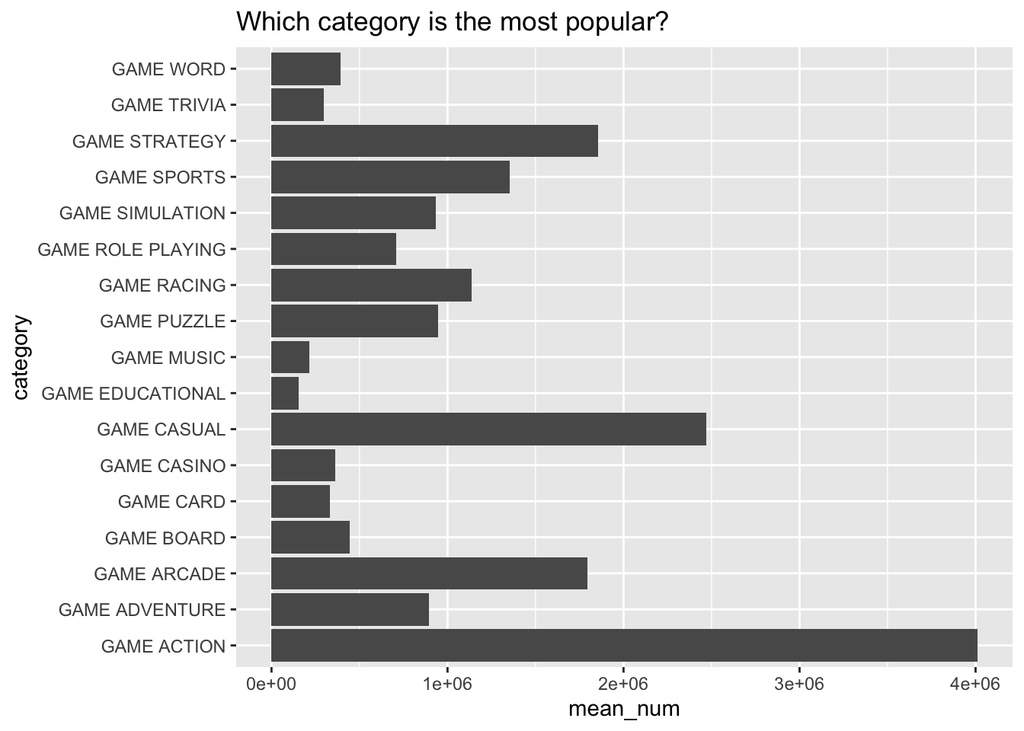

The reason why we choose this chart to illustrate the relationship between the game genre and its total number of rating is because it allows us to view the disturbance of different genre vividly. As the chart shows, Game action has the most rating number of all game genres in Google Play store, which followed by Casual Game and Strategies Game.

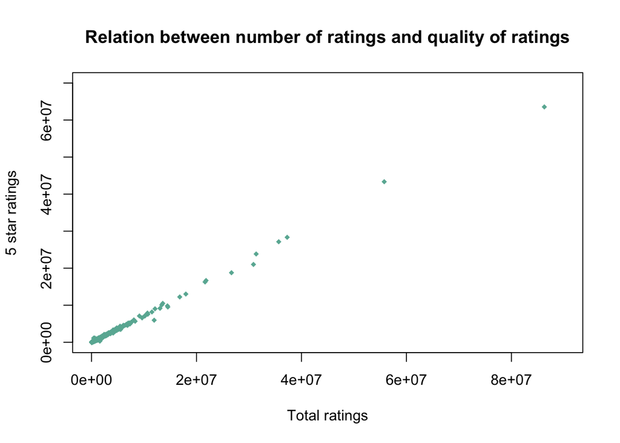

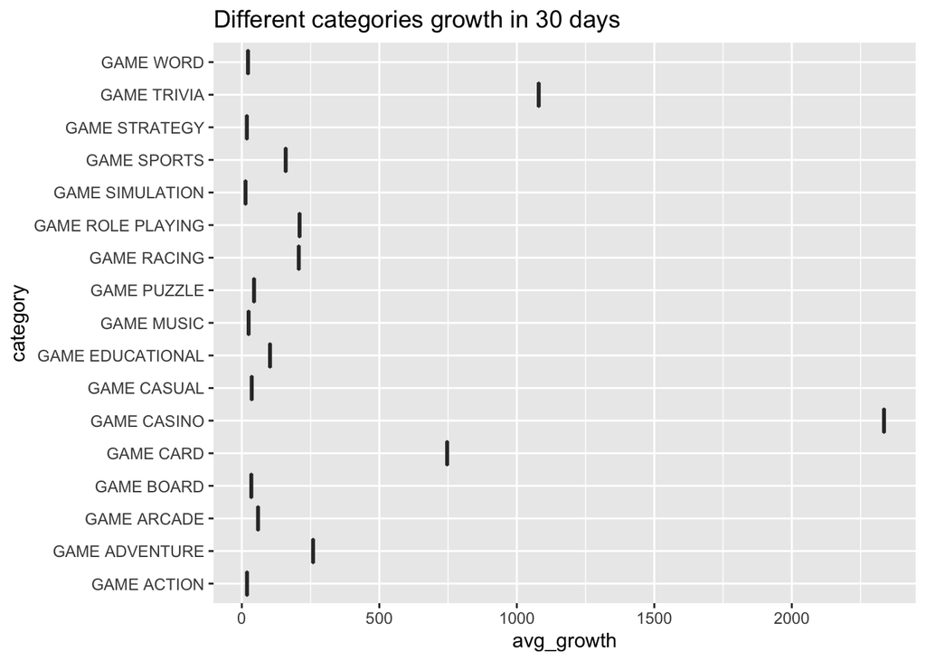

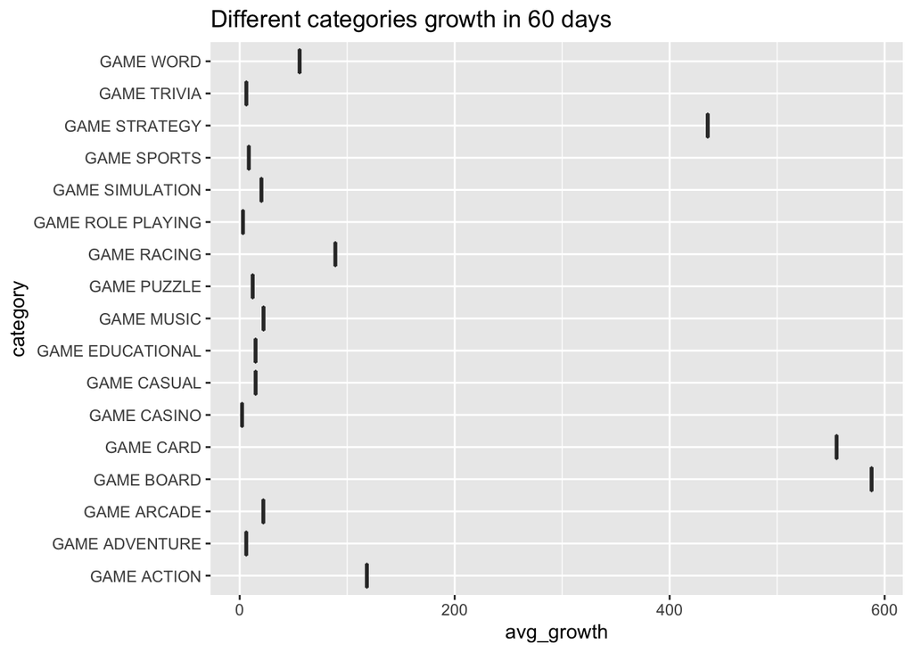

The reason why we choose these two charts to illustrate the relationship between the game genre and its growth of 30 days and 60 days is because these two charts best display the mean of each game genre, which helps to identify which game genre has the fastest rate of growth compared with others. According to the charts, Casino game possesses the most growth rate of 30 days while the Board Games has the most growth rate of 60 days. Action Game lose its top in growth rate, which could be abnormal considered its high amount of rating and 5 stars comment.